# Book Search Engine for BookLovers

### Reg. No: 18BCE1146

### Name: MEHUL RAJ

## Setup

setwd(“C:/Users/dell/Desktop/study material/college/sem5/data analytics/project”)

## What problem are you trying to solve?

I went through the goodReads dataset that I have taken for the Data Analytics Project. I started exploring on how Search Engines work. For the project, I would work on how we can improve the data selection ( here books ) for a user. Let me walk you through it. We will give options to the users, where they search for a book using: - Values directly: Example - author, ratings, title and more - Range: A user might be not be too sure about his or her choices, and might want to explore more results. Example - ratings between 3 - 5 or reviews more than 1000. This would give users more space to choose and look for a book they want to read.

## What data have you chosen?(Chosen Dataset, Source of dataset, Description of dataset, basic commands to describe dataset)

Chosen Dataset: GoodReads  
Source of DataSet: Kaggle  
Description of the DataSet: The dataSet contains all the basic attributes of 1000+ books including reviews, ratings, title and more.  
Basic Commands to describe Dataset:

```r
dataBook = read.csv("book1000k-1100k.csv")
dim(dataBook)
```

```
## [1] 39705    20
```

```r
names(dataBook)
```

```
##  [1] "Id"                    "Name"                  "Authors"
##  [4] "ISBN"                  "Rating"                "PublishYear"
##  [7] "PublishDay"            "PublishMonth"          "Publisher"
## [10] "RatingDist5"           "RatingDist4"           "RatingDist3"
## [13] "RatingDist2"           "RatingDist1"           "RatingDistTotal"
## [16] "CountsOfReview"        "Language"              "pagesNumber"
## [19] "Description"           "Count.of.text.reviews"
```

```r
ncol(dataBook)
```

```
## [1] 20
```

```r
nrow(dataBook)
```

```
## [1] 39705
```

## Frame your objectives

My Working area:

## Data PreProcessing

```r
#PreProcessing
library(dplyr)
myDat = read.csv("book1000k-1100k.csv")

d1 = myDat$RatingDist1
d2 = myDat$RatingDist2
d3 = myDat$RatingDist3
d4 = myDat$RatingDist4
d5 = myDat$RatingDist5
Total = myDat$RatingDistTotal

d1 = strsplit(d1, ":")
for(i in 1:length(d1)){
 d1[[i]] = d1[[i]][2]
}
d1 = as.integer(d1)

d2 = strsplit(d2, ":")
for(i in 1:length(d2)){
  d2[[i]] = d2[[i]][2]
}
d2 = as.integer(d2)

d3 = strsplit(d3, ":")
for(i in 1:length(d3)){
  d3[[i]] = d3[[i]][2]
}
d3 = as.integer(d3)

d4 = strsplit(d4, ":")
for(i in 1:length(d4)){
  d4[[i]] = d4[[i]][2]
}
d4 = as.integer(d4)

d5 = strsplit(d5, ":")
for(i in 1:length(d5)){
  d5[[i]] = d5[[i]][2]
}
d5 = as.integer(d5)
```

### Model1:

VALUE And RANGE BASED SEARCH  
- Author’s Name: Value Based  
- Publish Date,Year,Month: Value and Range Bases  
Can even show the time of the year when most of the books have been published based on month  
- Ratings: Value and Range Based  
Here counting of the ratings,ratings distribution, average rating  
- Number of People Views: This has always helped Google, Youtube , spotify to keep search as optimized as possible.

```r
#Model1

book_Name = filter(myDat, myDat$Name == 'Individuals in Context: A Practical Guide to Client Centered Practice')
book_Name$Name
```

```
## [1] "Individuals in Context: A Practical Guide to Client Centered Practice"
```

```r
#Books filter based on Author
book_Author = filter(myDat, myDat$Authors == 'Virginie Fowler Elbert')
book_Author$Name
```

```
## [1] "Shell Craft"                        "Orchids of the World Coloring Book"
```

```r
#Books filter based on Ratings
book_Rating5 = filter(myDat, d5>3)
head(book_Rating5$Name, 10)
```

```
##  [1] "The King At The Door"
##  [2] "Giotto: The Scrovegni Chapel, Padua"
##  [3] "Larky Mavis"
##  [4] "The Holy Longing"
##  [5] "Haroun and the Sea of Stories"
##  [6] "The Desire and Pursuit of the Whole: A Romance of Modern Venice"
##  [7] "Brilliant!: The Blinding Enlightenment of Nikola Tesla"
##  [8] "Feu PÃ¢le"
##  [9] "Anne of Green Gables"
## [10] "Getting Home Alive"
```

```r
book_Rating4 = filter(myDat, d4>5)
head(book_Rating4$Name, 10)
```

```
##  [1] "The King At The Door"
##  [2] "Larky Mavis"
##  [3] "The Holy Longing"
##  [4] "Haroun and the Sea of Stories"
##  [5] "The Desire and Pursuit of the Whole: A Romance of Modern Venice"
##  [6] "Feu PÃ¢le"
##  [7] "Anne of Green Gables"
##  [8] "Getting Home Alive"
##  [9] "The Parisian Woman's Guide to Style"
## [10] "Virginie: Her Two Lives"
```

```r
book_Rating3 = filter(myDat, d3>2)
head(book_Rating3$Name, 10)
```

```
##  [1] "The King At The Door"
##  [2] "Larky Mavis"
##  [3] "Computers, Chess and Long-Range Planning"
##  [4] "The Holy Longing"
##  [5] "The Desire and Pursuit of the Whole: A Romance of Modern Venice"
##  [6] "Anne of Green Gables"
##  [7] "Getting Home Alive"
##  [8] "Turning Custom Duck and Game Calls: The Complete Guide for Craftsmen, Collectors, and Outdoorsmen"
##  [9] "In the Sewers of Lvov: A Heroic Story of Survival from the Holocaust"
## [10] "The Parisian Woman's Guide to Style"
```

```r
book_Rating2 = filter(myDat, d2<5)
head(book_Rating2$Name, 10)
```

```
##  [1] "Flight from Eden"
##  [2] "Roommates Again"
##  [3] "The King At The Door"
##  [4] "Giotto: The Scrovegni Chapel, Padua"
##  [5] "Computers, Chess and Long-Range Planning"
##  [6] "The Holy Longing"
##  [7] "Yearning to Breathe Free: Robert Smalls of South Carolina and His Families"
##  [8] "The Desire and Pursuit of the Whole: A Romance of Modern Venice"
##  [9] "Brilliant!: The Blinding Enlightenment of Nikola Tesla"
## [10] "Getting Home Alive"
```

```r
book_Rating1 = filter(myDat, d1<1)
head(book_Rating1$Name, 10)
```

```
##  [1] "Flight from Eden"
##  [2] "The King At The Door"
##  [3] "Giotto: The Scrovegni Chapel, Padua"
##  [4] "The Holy Longing"
##  [5] "Yearning to Breathe Free: Robert Smalls of South Carolina and His Families"
##  [6] "Brilliant!: The Blinding Enlightenment of Nikola Tesla"
##  [7] "Getting Home Alive"
##  [8] "Getting Home Alive! Memories of Car Collecting Before It Got Civilized"
##  [9] "Turning Custom Duck and Game Calls: The Complete Guide for Craftsmen, Collectors, and Outdoorsmen"
## [10] "Shell Craft"
```

```r
book_Total = filter(myDat, myDat$RatingDistTotal < 50)
head(book_Total$Name, 10)
```

```
##  [1] "Flight from Eden"
##  [2] "Roommates Again"
##  [3] "The King At The Door"
##  [4] "Giotto: The Scrovegni Chapel, Padua"
##  [5] "Computers, Chess and Long-Range Planning"
##  [6] "The Holy Longing"
##  [7] "Yearning to Breathe Free: Robert Smalls of South Carolina and His Families"
##  [8] "The Desire and Pursuit of the Whole: A Romance of Modern Venice"
##  [9] "Brilliant!: The Blinding Enlightenment of Nikola Tesla"
## [10] "Getting Home Alive! Memories of Car Collecting Before It Got Civilized"
```

```r
# Books filter based on count of reviews
book_countReview = filter(myDat, myDat$CountsOfReview < 10)
head(book_countReview$Name, 10)
```

```
##  [1] "Flight from Eden"
##  [2] "Roommates Again"
##  [3] "The King At The Door"
##  [4] "Giotto: The Scrovegni Chapel, Padua"
##  [5] "Larky Mavis"
##  [6] "Computers, Chess and Long-Range Planning"
##  [7] "The Holy Longing"
##  [8] "Yearning to Breathe Free: Robert Smalls of South Carolina and His Families"
##  [9] "There and Back Again: An Actor's Tale"
## [10] "The Desire and Pursuit of the Whole: A Romance of Modern Venice"
```

```r
#Multiple filter simultaneously

book_Ratings = filter(myDat, d5>3 , d4<3, d3>2, d2>3, d1 == 1)
head(book_Ratings$Name, 10)
```

```
## [1] "Pandora's Box: The Changing Aspects of a Mythical Symbol"
## [2] "Are You Made for Each Other?: The Relationship Quiz Book"
## [3] "Letters to Penthouse IV: They Stop at Nothing -- and They Tell It All!"
## [4] "Lucio Fulci: Beyond the Gates: A Tribute to the Maestro"
## [5] "Raggedy Ann & Andy School Day Adventure"
## [6] "Hidden Secrets: The Complete History of Espionage and the Technology Used to Support It"
## [7] "A Messy Job I Never Did See a Girl Do"
```

```r
book_VFElbert = filter(myDat, myDat$Authors == 'Virginie Fowler Elbert' & myDat$RatingDistTotal > 2)
book_VFElbert$Name
```

```
## [1] "Shell Craft"
```

```r
#Books Published in My Birthday
book_Bdate = filter(myDat, PublishYear==2000 & PublishDay==28 & PublishMonth==8)
book_Bdate$Name
```

```
## [1] "Somerled: And the Emergence of Gaelic Scotland"
## [2] "Transformations in Slavery: A History of Slavery in Africa"
## [3] "The Disney Films"
## [4] "From .com to .Profit: Inventing Business Models That Deliver Value and Profit"
```

### Model2:

Priority Based Search Suggestion  
After exploring how Google Search Works, so basically what this does is that when a particular person searches for the particular book based on his desires, he will get one or group of books, he will choose one or more from these. The book(s) that will be chosen will by him, the search engine engine will increment the book priority by one, so for the next person who is looking for a book will have optimized search result based on the Priority and will be able to choose if he is also looking for the same type of book.

```r
#Model2
priorty = rep(0, length(d1))
Book_Priority = cbind(myDat, priorty)

head(Book_Priority$Name, 10)
```

```
##  [1] "Flight from Eden"
##  [2] "Roommates Again"
##  [3] "The King At The Door"
##  [4] "Giotto: The Scrovegni Chapel, Padua"
##  [5] "Larky Mavis"
##  [6] "Computers, Chess and Long-Range Planning"
##  [7] "The Holy Longing"
##  [8] "Yearning to Breathe Free: Robert Smalls of South Carolina and His Families"
##  [9] "A Wild Yearning"
## [10] "Haroun and the Sea of Stories"
```

```r
book_VFElbert = filter(Book_Priority, Book_Priority$Authors == 'Virginie Fowler Elbert')
book_VFElbert$Name
```

```
## [1] "Shell Craft"                        "Orchids of the World Coloring Book"
```

```r
#chosen_book = readline(prompt="Enter the Book You want: ")
chosen_book = "Shell Craft"

for(i in 1:length(d1)){
  if(chosen_book == Book_Priority$Name[i]){
    Book_Priority$priorty[i] =  Book_Priority$priorty[i] + 1
  }
}

Book_Priority = arrange(Book_Priority, desc(Book_Priority$priorty))
head(Book_Priority$Name, 10)
```

```
##  [1] "Shell Craft"
##  [2] "Flight from Eden"
##  [3] "Roommates Again"
##  [4] "The King At The Door"
##  [5] "Giotto: The Scrovegni Chapel, Padua"
##  [6] "Larky Mavis"
##  [7] "Computers, Chess and Long-Range Planning"
##  [8] "The Holy Longing"
##  [9] "Yearning to Breathe Free: Robert Smalls of South Carolina and His Families"
## [10] "A Wild Yearning"
```

### Model3:

Priorities given to Filters  
- Priorities to the filters that is Mentioned in Model1 will be given. Default values will be given and user can make changes based on his requirements as well.

```r
#Model3
# Filter Prioritizing for books:
#
# 1. Name of the book
# 2. Name of the  author
# 3. Rating with 4+
# 4. Number of reviews
# 5. Number of pages.

# Name_Author = readline(prompt = "Enter Name of the Author: ")
# Name_Book = readline(prompt = "Enter Name of the Book: ")
# Rating_Book = readline(prompt = "Enter number of Ratings: ")
# Rating_Book = as.integer(Rating_Book)
# Number_of_reviews = readline(prompt = "Enter number of reviews: ")
# Number_of_reviews = as.integer(Number_of_reviews)
# Number_of_pages = readline(prompt = "Enter number of pages: ")
# Number_of_pages = as.integer(Number_of_pages)
Name_Author = "Virginie Fowler Elbert"
Name_Book = ""
Rating_Book = 0
Number_of_reviews = 0
Number_of_pages = 50


#Main filter
Book = filter(Book_Priority, Book_Priority$Name ==  Name_Book)
Book
```

```
##  [1] Id                    Name                  Authors
##  [4] ISBN                  Rating                PublishYear
##  [7] PublishDay            PublishMonth          Publisher
## [10] RatingDist5           RatingDist4           RatingDist3
## [13] RatingDist2           RatingDist1           RatingDistTotal
## [16] CountsOfReview        Language              pagesNumber
## [19] Description           Count.of.text.reviews priorty
## <0 rows> (or 0-length row.names)
```

```r
#Taking Secondary Filter that is important
Book = filter(Book_Priority,  Book_Priority$Authors ==  Name_Author)
Book = filter(Book, Book$Rating > Rating_Book)
Book = filter(Book, Book$CountsOfReview >  Number_of_reviews )
Book = filter(Book, Book$pagesNumber > Number_of_pages)



#Using Model 2 after Model 3
Book$Name
```

```
## [1] "Shell Craft"
```

```r
n = length(Book$Name)
if(n > 1){
  chosen_book = readline(prompt="Enter the Book You want: ")
}else{
  chosen_book = Book$Name
}

for(i in 1:length(d1)){
  if(chosen_book == Book_Priority$Name[i]){
    Book_Priority$priorty[i] =  Book_Priority$priorty[i] + 1
  }
}

Book_Priority = arrange(Book_Priority, desc(Book_Priority$priorty))
head(Book_Priority$Name, 10)
```

```
##  [1] "Shell Craft"
##  [2] "Flight from Eden"
##  [3] "Roommates Again"
##  [4] "The King At The Door"
##  [5] "Giotto: The Scrovegni Chapel, Padua"
##  [6] "Larky Mavis"
##  [7] "Computers, Chess and Long-Range Planning"
##  [8] "The Holy Longing"
##  [9] "Yearning to Breathe Free: Robert Smalls of South Carolina and His Families"
## [10] "A Wild Yearning"
```

## Visualization

```r
#Visualization for Ratings
num = 0
for(i in 1:length(d1)){
  if( Book$Name == Book_Priority$Name[i]){
    num = i
    print(num)
  }
}
```

```
## [1] 1
```

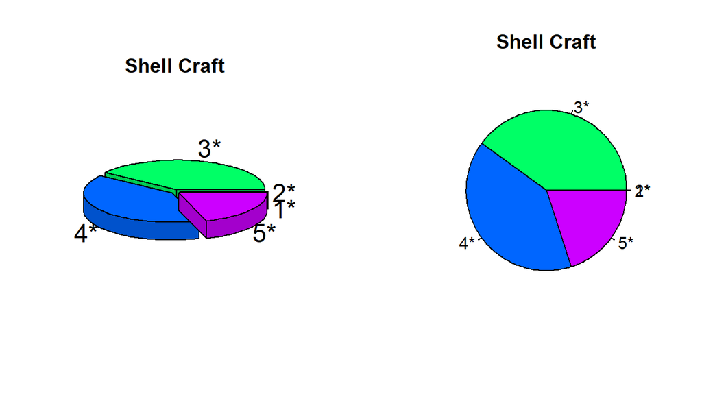

```r
r1 = strsplit(Book_Priority$RatingDist1[num], ":")
r1 = r1[[1]][2]
r1 = as.integer(r1)

r2 = strsplit(Book_Priority$RatingDist2[num], ":")
r2 = r2[[1]][2]
r2 = as.integer(r2)

r3 = strsplit(Book_Priority$RatingDist3[num], ":")
r3 = r3[[1]][2]
r3 = as.integer(r3)

r4 = strsplit(Book_Priority$RatingDist4[num], ":")
r4 = r4[[1]][2]
r4 = as.integer(r4)

r5 = strsplit(Book_Priority$RatingDist5[num], ":")
r5 = r5[[1]][2]
r5 = as.integer(r5)
Ratings = c(r1, r2, r3, r4, r5)
labeling = c("1*", "2*", "3*", "4*", "5*")
library(plotrix)
par(mfrow=c(1,2))
pie3D(Ratings, labels = labeling, explode = 0.05, main=Book$Name, col=rainbow(length(labeling)))
pie(Ratings, labels = labeling, main=Book$Name, col=rainbow(length(labeling)))
```

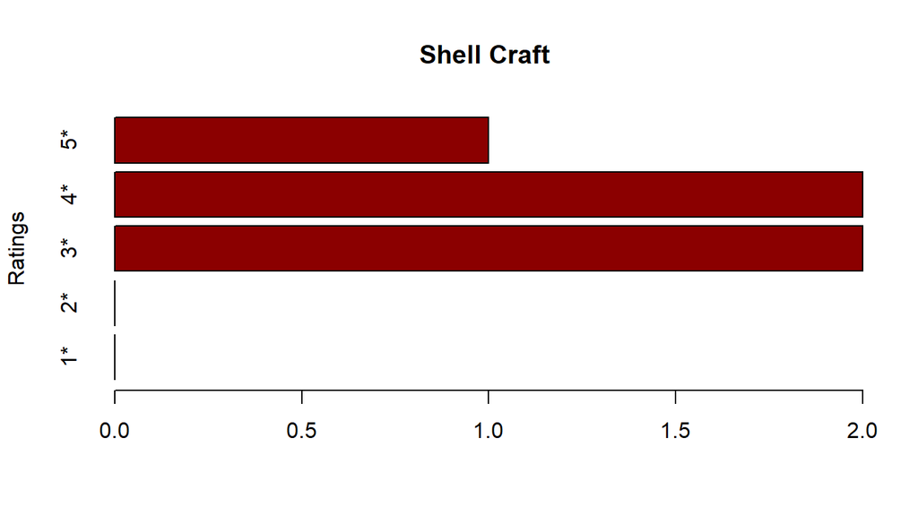

```r
par(mfrow=c(1,1))
barplot(Ratings,ylab = "Ratings", names.arg = labeling, horiz=T,col="darkred", main = chosen_book)
```

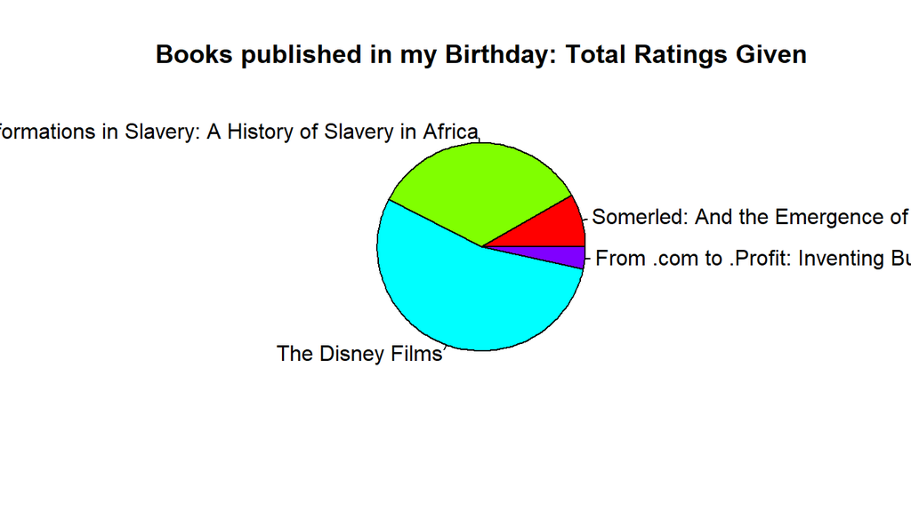

```r
#Visualization of Books published in my Birth Date
Ratings = c(book_Bdate$RatingDistTotal)
labeling = c(book_Bdate$Name)
pie(Ratings, labels = labeling,
    main = "Books published in my Birthday: Total Ratings Given",
    col=rainbow(length(labeling)))
```

```r
#Number of books Published Every Year
library(plyr)
books = ddply(Book_Priority,~PublishYear,summarise,books=length(unique(Book_Priority$PublishYear)))
books
```

```
##    PublishYear books
## 1         1898    95
## 2         1899    95
## 3         1900    95
## 4         1905    95
## 5         1907    95
## 6         1921    95
## 7         1923    95
## 8         1925    95
## 9         1928    95
## 10        1929    95
## 11        1930    95
## 12        1931    95
## 13        1932    95
## 14        1935    95
```

[output cut: 81 more lines]

## Is there any work previously reported on the problem and the data? If so, discuss it here.

A task where a book is selected based on the concept where Book(s) with highest text review is selected.

rmarkdown::render(“review1_template.Rmd”)